# Analýza herních dat NBA sezóny 2023/24

Martin Heger

# Úvod

Tento dokument analyzuje data ze sezóny NBA a zaměřuje se na rozdíly ve skóre mezi domácími a hostujícími týmy, celkový počet výher týmu a statistiky jednotlivých hráčů.

# Připojení k databázy

```r
# Načtení knihoven
library(DBI)
library(odbc)
library(dplyr)
library(dbplyr)
library(ggplot2)
library(kableExtra)
library(shiny)
library(lubridate)
library(tidyr)
library(forcats)
library(stringr)





# Připojení k databázi
con <- dbConnect(odbc::odbc(),
                 Driver = "SQL Server",
                 Server = "LAPTOP-STOB8T44\\SQLEXPRESS",
                 Database = "mahe_projekt_NBA")
```

### Načtení dat

Zde využíváme funkci **dbGetQuery** pro provedení dotazu a načtení výsledku do R, a následně s nimi pracujeme již v R. Druhou možností je použití **dbReadTable**, která načte do R celou tabulku. Zvolili jsme první možnost, protože je jednodušší poté změnit, které sloupce nám například do R stačí načíst, když nechceme všechny. Třetí možností je knihovna **dbplyr** a příkaz **tbl** – data se nenačítají celá do R paměti, ale místo toho **dbplyr** generuje SQL dotazy, které se provádějí přímo na serveru. Při menších datech nevzniká s našim postupem problém. Při větších datech může být výhodnější používat **dbplyr**, na druhou stranu však automatické překládání na dotaz do SQL může přinášet při složitějších konstrukcích problémy.

```r
# Načtení všech tabulek
nba_zapasy      <- dbGetQuery(con, "SELECT * FROM nba_zapasy")
nba_sezona_hraci <- dbGetQuery(con, "SELECT * FROM nba_sezona_hraci")
nba_hraci       <- dbGetQuery(con, "SELECT * FROM nba_hraci")
nba_tymy        <- dbGetQuery(con, "SELECT * FROM nba_tymy")
nba_draft       <- dbGetQuery(con, "SELECT * FROM nba_draft")
nba_divize      <- dbGetQuery(con, "SELECT * FROM nba_divize")
nba_konference  <- dbGetQuery(con, "SELECT * FROM nba_konference")

# Odpojení od DB
dbDisconnect(con)

# Výpis struktur
#str(nba_zapasy)
#str(nba_sezona_hraci)
#str(nba_hraci)
#str(nba_tymy)
#str(nba_draft)
#str(nba_divize)
#str(nba_konference)
```

# Začínáme s analýzou

## Týmové statistiky

Nejprve se budeme zabývat statistikami týmů a zápasů mezi nimi.

### Histogram rozdílů skóre

Nejprve získáme rozdíl skóre mezi domácím a hostujícím týmem. Použijeme **absolutní hodnotu**, protože nám nezáleží na tom, kdo vyhrál, pouze na velikosti rozdílu ve skóre. Rozdíly jsou **rozděleny do kategorií**, abychom mohli lépe porozumět tomu, jak těsné byly zápasy v jednotlivých rozmezích.

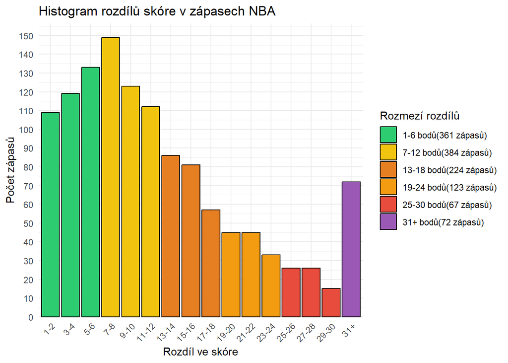

```r
# Kategorie rozdílů skore po dvou bodech a nadkategorie po 6 bodech
nba_zapasy <- nba_zapasy %>%
  mutate(diference_skore = abs(domaci_skore - hoste_skore)) %>%
  filter(diference_skore > 0) %>%
  mutate(
    kategorie = case_when(
      diference_skore <= 2   ~ "1-2",  diference_skore <= 4   ~ "3-4",
      diference_skore <= 6   ~ "5-6",  diference_skore <= 8   ~ "7-8",
      diference_skore <= 10  ~ "9-10", diference_skore <= 12  ~ "11-12",
      diference_skore <= 14  ~ "13-14",diference_skore <= 16  ~ "15-16",
      diference_skore <= 18  ~ "17-18",diference_skore <= 20  ~ "19-20",
      diference_skore <= 22  ~ "21-22",diference_skore <= 24  ~ "23-24",
      diference_skore <= 26  ~ "25-26",diference_skore <= 28  ~ "27-28",
      diference_skore <= 30  ~ "29-30",TRUE                   ~ "31+"
    ),
    nadkategorie = case_when(
      diference_skore <= 6   ~ "1-6 bodů",  diference_skore <= 12  ~ "7-12 bodů",
      diference_skore <= 18  ~ "13-18 bodů",diference_skore <= 24  ~ "19-24 bodů",
      diference_skore <= 30  ~ "25-30 bodů",TRUE                   ~ "31+ bodů"
    )
  )


# Pořadí kategorií (pro grafy a legendy) neboť kategroie a nadkategorie jsou vytvořené jako textové řetězce a R je defaultně v grafech řadí alfabeticky
nba_zapasy$kategorie <- factor(nba_zapasy$kategorie,
                               levels = c("1-2", "3-4", "5-6", "7-8",
                                           "9-10", "11-12", "13-14", "15-16",
                                           "17-18", "19-20", "21-22", "23-24",
                                           "25-26", "27-28", "29-30", "31+"))

nba_zapasy$nadkategorie <- factor(nba_zapasy$nadkategorie,
                                  levels = c("1-6 bodů", "7-12 bodů", "13-18 bodů","19-24 bodů", "25-30 bodů", "31+ bodů"))

# Součty podle kategorie a nadkategorie
soucty <- nba_zapasy %>%
  count(kategorie,nadkategorie)


soucty1 <- nba_zapasy %>%
  count(kategorie,nadkategorie) %>%
  group_by(nadkategorie) %>%
  summarise(pocet_zapasu = sum(n)) %>%
  ungroup()

# Barevné přechody mezi nadkategoriemi
barvy <- c("1-6 bodů" = "#2ECC71",     # zelená
           "7-12 bodů" = "#F1C40F",    # žlutá
           "13-18 bodů" = "#E67E22",   # oranžová
           "19-24 bodů" = "#F39C12",   # tmavší žlutá
           "25-30 bodů" = "#E74C3C",   # červená
           "31+ bodů" = "#9B59B6")     # fialová

# Histogram
ggplot(soucty, aes(x = kategorie, y = n, fill = nadkategorie)) +
  geom_bar(stat = "identity", color = "black") +
  scale_fill_manual(values = barvy,
                    name = "Rozmezí rozdílů",
                    labels = paste(levels(soucty$nadkategorie),
                                   "(", soucty1$pocet_zapasu, " zápasů)", sep = "")) +
  scale_y_continuous(
    breaks = seq(0, max(soucty$n) + 10, by = 10),
    expand = expansion(mult = c(0, 0.05))
  ) +
  labs(
    title = "Histogram rozdílů skóre v zápasech NBA",
    x = "Rozdíl ve skóre",
    y = "Počet zápasů"
  ) +
  theme_minimal() +
  theme(
    legend.position = "right",
    axis.text.x = element_text(angle = 45, hjust = 1)
  )
```

### Vykreslení boxplotu s popisky

Nyní ještě vykreslíme boxplot, pro lepší vizualizaci **mediánu**, **interkvartilového rozpětí** a **intervalu spolehlivosti**. Při tvorbě se objevil problém spojený právě s databází. Díky vykreslení odlehlých zápasů jsme si všimli, že se zobrazuje rozdíl mezi skóre týmu více než 100. Po prozkoumání dat v databázi se našel problém. Špatná hodnota v jednom jediném zápasu. **POZOR** na zdroje a integritu dat!

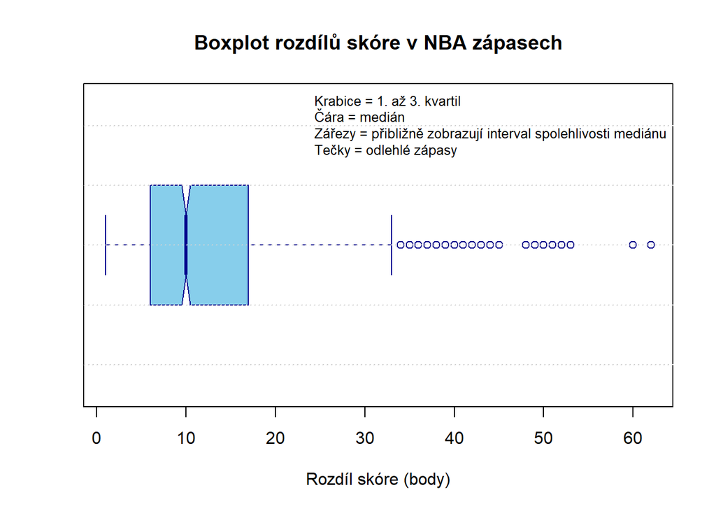

```r
# Vykreslení boxplotu s popisky
boxplot(nba_zapasy$diference_skore,
        main = "Boxplot rozdílů skóre v NBA zápasech",
        xlab = "Rozdíl skóre (body)",
        col = "skyblue",
        border = "darkblue",
        notch = TRUE,        # zářez ukazuje konfidenční interval mediánu
        horizontal = TRUE,   # boxplot bude vodorovný
        outline = TRUE)      # zobrazí i odlehlé body
grid(nx = NA, ny = NULL, col = "lightgray", lty = "dotted")
legend("topright",
       legend = c("Krabice = 1. až 3. kvartil",
                  "Čára = medián",
                  "Zářezy = přibližně zobrazují interval spolehlivosti mediánu",
                  "Tečky = odlehlé zápasy"),
       bty = "n",            # Bez rámečku okolo legendy
       cex = 0.8,            # Velikost textu
       text.col = "black")   # Barva textu legendy
```

### Heatmapa

Heatmapa skóre domácích týmů podle měsíců. Heatmapa vizualizuje průměrné skóre jednotlivých domácích týmů v průběhu sezóny. Umožňuje rychle odhalit výkonnostní výkyvy mezi měsíci.

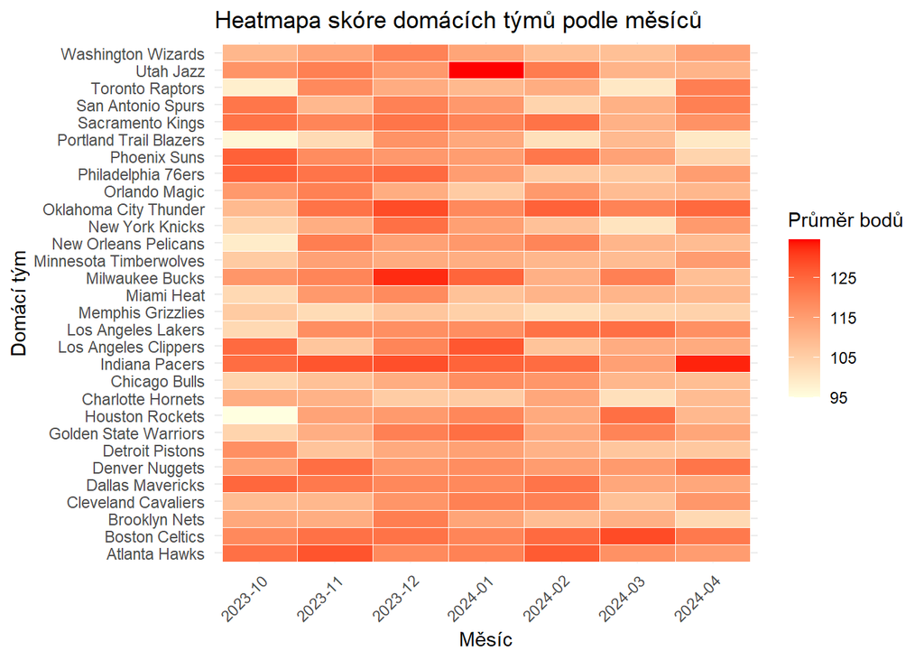

```r
# Spojení s tabulkou nba_tymy a výpočet průměrů
heatmapa_data <- nba_zapasy %>%
  mutate(mesic = format(as.Date(datum), "%Y-%m")) %>%
  group_by(id_tym_domaci, mesic) %>%
  summarise(prumer_bodu = mean(domaci_skore), .groups = "drop") %>%
  left_join(nba_tymy, by = c("id_tym_domaci" = "tym_id"))  # spojení pro název týmu

# Vykreslení heatmapy
ggplot(heatmapa_data, aes(x = mesic, y = nazev, fill = prumer_bodu)) +
  geom_tile(color = "white") +
  scale_fill_gradient(low = "lightyellow", high = "red") +
  labs(
    title = "Heatmapa skóre domácích týmů podle měsíců",
    x = "Měsíc", y = "Domácí tým", fill = "Průměr bodů"
  ) +
  theme_minimal() +
  theme(axis.text.x = element_text(angle = 45, hjust = 1))
```

### Vývoj průměrných bodů v zápasech po týdnech v čase

Nyní se podíváme na průměrné body v zápasech po jednotlivých hracích týdnech. Budeme pozorovat jak se v čase mění ofenzivní nasazení týmů v lize a pokusíme se výsledný graf proložit spojitou křivkou.

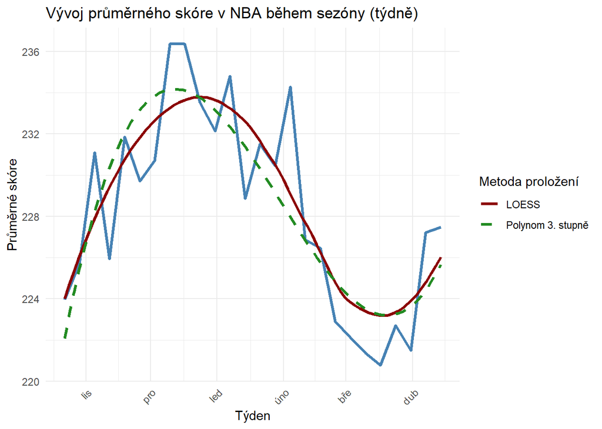

```r
# Vytvoření týdenních dat
skore_v_case <- nba_zapasy %>%
  mutate(tyden = floor_date(as.Date(datum), "week")) %>%
  group_by(tyden) %>%
  summarise(prumer_skore = mean(domaci_skore + hoste_skore))

# GRAF
ggplot(skore_v_case, aes(x = tyden, y = prumer_skore)) +
  geom_line(color = "steelblue", size = 1.2) +

  # Proložení LOESS
  geom_smooth(aes(color = "LOESS"), method = "loess", se = FALSE, size = 1.2) +

  # Proložení polynomem 3. stupně
  geom_smooth(aes(color = "Polynom 3. stupně"),
              method = "lm", formula = y ~ poly(x, 3),
              se = FALSE, size = 1.2, linetype = "dashed") +

  scale_color_manual(values = c("LOESS" = "darkred", "Polynom 3. stupně" = "forestgreen")) +

  labs(
    title = "Vývoj průměrného skóre v NBA během sezóny (týdně)",
    x = "Týden", y = "Průměrné skóre", color = "Metoda proložení"
  ) +

  theme_minimal() +
  theme(
    legend.position = "right",
    axis.text.x = element_text(angle = 45, hjust = 1)
  )
```

```r
# -----ALTERNATIVY-----

# geom_smooth(method = "loess"):
# + Výhody: nelineární, dobře zachycuje lokální trendy, žádná nutnost volby modelu
# - Nevýhody: pomalejší pro velká data, může přepasovat (overfitting)

# geom_smooth(method = "lm", formula = y ~ poly(x, 3)):
# + Výhody: jednoduchý globální model, dobře čitelný
# - Nevýhody: náchylný k pod/přepasování, pokud zvolen špatný stupeň

# Další možné metody:
# - method = "gam" (Generalized Additive Models): flexibilní jako LOESS, ale lépe škáluje
```

### Koláčový graf výher týmů

Nyní zobrazíme **koláčové grafy** poddílů výher týmů ve všech 6 divizích. Zde se vyskytoval problém se spojováním mnoha záznamů a celý R Markdown dokument se následně r**enderoval déle, než bylo vhodné.** V tomto případě však při prozkoumání **nebyl problém z pamětí v R.** Je však třeba brát na paměť, že náš způsob někdy může být kamenem úrazu.

```r
# Spočítání výher pro týmy v zápasech
nba_vitezstvi <- nba_zapasy %>%
  mutate(vitez_id = ifelse(domaci_skore > hoste_skore, id_tym_domaci, id_tym_hoste)) %>%
  count(vitez_id, name = "vitezstvi")

# Spojení informací o týmech (divize, konference)
info_tymy <- nba_tymy %>%
  left_join(nba_divize, by = "divize_id") %>%
  left_join(nba_konference, by = "konference_id") %>%
  select(tym_id = tym_id, tym = zkratka.x, divize = nazev.y, konference = zkratka)

# Spojení s výhrami
nba_prehled <- info_tymy %>%
  left_join(nba_vitezstvi, by = c("tym_id" = "vitez_id")) %>%
  mutate(vitezstvi = replace_na(vitezstvi, 0)) %>%
  select(tym_id, tym, divize, konference, vitezstvi) %>%
  arrange(divize, desc(vitezstvi))  # Seřazení podle divize a výher

# Spočítání procent výher v rámci divize
nba_prehled_procent <- nba_prehled %>%
  group_by(divize) %>%
  mutate(podil = vitezstvi / sum(vitezstvi)) %>%
  ungroup()
nba_prehled_procent
```

```
## # A tibble: 30 × 6
##    tym_id tym   divize     konference vitezstvi  podil
##     <int> <chr> <chr>      <chr>          <int>  <dbl>
##  1      1 BOS   Atlantická EAST              64 0.294
##  2      3 NYK   Atlantická EAST              50 0.229
##  3      4 PHI   Atlantická EAST              47 0.216
##  4      2 BKN   Atlantická EAST              32 0.147
##  5      5 TOR   Atlantická EAST              25 0.115
##  6     10 MIL   Centrální  EAST              49 0.249
##  7      7 CLE   Centrální  EAST              48 0.244
##  8      9 IND   Centrální  EAST              47 0.239
##  9      6 CHI   Centrální  EAST              39 0.198
## 10      8 DET   Centrální  EAST              14 0.0711
## # ℹ 20 more rows
```

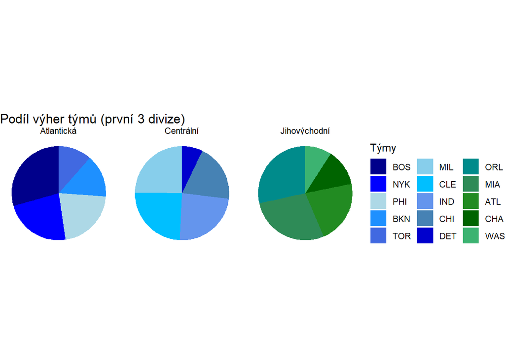

```r
# Vytvoření barevné palety
colors <- c(
  "darkblue", "blue", "lightblue", "dodgerblue", "royalblue", "skyblue", "deepskyblue", "cornflowerblue", "steelblue", "mediumblue",
  "darkcyan", "seagreen", "forestgreen", "darkgreen", "mediumseagreen",
  "darkred", "firebrick", "#DC143C", "red", "tomato", "orangered", "darkorange", "orange", "gold", "yellow",
  "lightyellow", "khaki", "yellowgreen", "#808000", "goldenrod"
)

# Uspořádání týmů podle pořadí v rámci divizí a výher
nba_prehled_procent <- nba_prehled_procent %>%
  arrange(divize, desc(vitezstvi)) %>%
  mutate(tym = factor(tym, levels = unique(tym)))

# Přiřazení barev podle pořadí týmů
nba_prehled_procent$barva <- colors[1:length(levels(nba_prehled_procent$tym))]

# Východní konference
divize_1 <- unique(nba_prehled_procent$divize)[1:3]

nba_cast1 <- nba_prehled_procent %>%
  filter(divize %in% divize_1)

ggplot(nba_cast1, aes(x = "", y = podil, fill = tym)) +
  geom_bar(stat = "identity", width = 1) +
  coord_polar(theta = "y") +
  facet_wrap(~ divize) +
  labs(title = "Podíl výher týmů (první 3 divize)") +
  theme_void() +
  theme(legend.position = "right") +
  scale_fill_manual(values = setNames(nba_cast1$barva, nba_cast1$tym)) +
  guides(fill = guide_legend(title = "Týmy", ncol = 3))
```

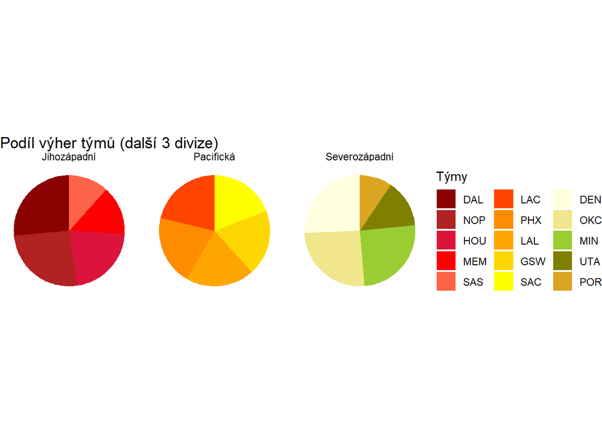

```r
# Západní konference
divize_2 <- unique(nba_prehled_procent$divize)[4:6]

nba_cast2 <- nba_prehled_procent %>%
  filter(divize %in% divize_2)

ggplot(nba_cast2, aes(x = "", y = podil, fill = tym)) +
  geom_bar(stat = "identity", width = 1) +
  coord_polar(theta = "y") +
  facet_wrap(~ divize) +
  labs(title = "Podíl výher týmů (další 3 divize)") +
  theme_void() +
  theme(legend.position = "right") +
  scale_fill_manual(values = setNames(nba_cast2$barva, nba_cast2$tym)) +
  guides(fill = guide_legend(title = "Týmy", ncol = 3))
```

## Interaktivní zobrazení statistik hráčů

Nyní se zaměříme na individuální výkony hráčů zobrazíme si tabulkově nejlepší hráče dle bodů v lize. Dále spočítáme ligové průměry některých statistik jako jsou body atp. Na závěr uděláme interaktivní vizualizaci, kdy si čtenář bude moct vybrat hráče, zobrazit jeho statistiky a porovnat je s ligovými průměry. Zde opět upozorňujeme na zdroj a formát dat, autor více rozebere na místě při prezentaci projektu.

```r
# Získání názvů týmů, za které hráč hrál
tymy_hracu <- nba_sezona_hraci %>%
  left_join(nba_tymy, by = "tym_id") %>%
  group_by(hrac_id) %>%
  summarise(
    tymy = paste(unique(zkratka), collapse = ", ")
  )


# Spojení statistik a týmů, KVULI forme dat a ulozeni v databazy nelze například použít mean(více se o tomto rozpovídám na prezentaci)
statistiky_hracu <- nba_sezona_hraci %>%
  group_by(hrac_id) %>%
  summarise(
    pocet_zapasu = sum(G),
    pocet_zapasu_z5 = sum(GS),
    celkem_body = sum(PTS * G, na.rm = TRUE),
    prumer_body_na_zapas = sum(PTS * G, na.rm = TRUE) / sum(G, na.rm = TRUE),
    celkem_doskoky = sum(TRB * G, na.rm = TRUE),
    prumer_doskoky_na_zapas = sum(TRB * G, na.rm = TRUE) / sum(G, na.rm = TRUE),
    celkem_asistence = sum(AST * G, na.rm = TRUE),
    prumer_asistence_na_zapas = sum(AST * G, na.rm = TRUE) / sum(G, na.rm = TRUE),
    efektivita_strelby = round(sum(eFG * G, na.rm = TRUE) / sum(G, na.rm = TRUE), 2),
    prumer_minut = round(sum(MP * G, na.rm = TRUE) / sum(G, na.rm = TRUE), 2)
  ) %>%
  left_join(nba_hraci, by = "hrac_id") %>%
  left_join(tymy_hracu, by = "hrac_id") %>%
  arrange(desc(prumer_body_na_zapas))


# Výpis top 10 hráčů s názvem týmu
top_10_hracu_body <- statistiky_hracu %>%
  select(jmeno_hrace, prumer_body_na_zapas, celkem_body, pocet_zapasu, tymy) %>%
  head(10)


ligovy_prumer_body <- mean(statistiky_hracu$prumer_body_na_zapas, na.rm = TRUE)
    ligovy_prumer_doskoky <- mean(statistiky_hracu$prumer_doskoky_na_zapas, na.rm = TRUE)
    ligovy_prumer_asistence <- mean(statistiky_hracu$prumer_asistence_na_zapas, na.rm = TRUE)


# Tabulka top 10 hráčů podle průměrných bodů
top_10_hracu_body %>%
  kable("html", col.names = c("Hráč", "Průměr bodů na zápas", "Celkem bodů", "Počet zápasů", "Týmy")) %>%
  kable_styling("striped", full_width = F) %>%
  column_spec(1, bold = TRUE, color = "blue") %>%
  column_spec(2:5, color = "darkgreen") %>%
  row_spec(0, bold = TRUE, background = "#f7f7f7")
```

| Hráč | Průměr bodů na zápas | Celkem bodů | Počet zápasů | Týmy |
| --- | --- | --- | --- | --- |
| Joel Embiid | 34.7 | 1353.3 | 39 | PHI |
| Luka Dončić | 33.9 | 2373.0 | 70 | DAL |
| Giannis Antetokounmpo | 30.4 | 2219.2 | 73 | MIL |
| Shai Gilgeous-Alexander | 30.1 | 2257.5 | 75 | OKC |
| Jalen Brunson | 28.7 | 2209.9 | 77 | NYK |
| Kevin Durant | 27.1 | 2032.5 | 75 | PHX |
| Devin Booker | 27.1 | 1842.8 | 68 | PHX |
| Jayson Tatum | 26.9 | 1990.6 | 74 | BOS |
| De’Aaron Fox | 26.6 | 1968.4 | 74 | SAC |
| Donovan Mitchell | 26.6 | 1463.0 | 55 | CLE |

```r
# Tabulka pro ligové průměry
data.frame(
  Statistika = c("Průměr bodů", "Průměr doskoků", "Průměr asistencí"),
  Hodnota = c(round(ligovy_prumer_body, 1), round(ligovy_prumer_doskoky, 1), round(ligovy_prumer_asistence, 1))
) %>%
  kable("html", col.names = c("Statistika", "Hodnota")) %>%
  kable_styling("striped", full_width = F) %>%
  column_spec(1, bold = TRUE, color = "red") %>%
  column_spec(2, color = "purple") %>%
  row_spec(0, bold = TRUE, background = "#f7f7f7")
```

| Statistika | Hodnota |
| --- | --- |
| Průměr bodů | 8.4 |
| Průměr doskoků | 3.4 |
| Průměr asistencí | 2.0 |

### Statistiky vybraného hráče a porovnání s průměry

Čtenář si bude moci vybrat libovolného hráče, zobrazit jeho souhrnné průměrné statistiky a porovnat je s ligovými průměry.

Interaktivní widget pro výběr hráče je dostupný pouze při lokálním spuštění s `runtime: shiny` a připojením na databázi — viz zdrojový kód výše.

```r
end_time <- Sys.time()
cas <- round(difftime(end_time, start_time, units = "secs"), 2)
cat("⏱️ Celkový čas knitování:", cas, "sekund")
```

```
## ⏱️ Celkový čas knitování: 9.39 sekund
```